# Notes 2: Simple Linear Regression

Cigarettes

## Simple Linear Regression Model for CO Output of Cigarettes

```r
cigs<-read_csv("cigarettes.csv")

cigs <- cigs |>
  clean_names()

str(cigs)
```

```
spc_tbl_ [25 × 5] (S3: spec_tbl_df/tbl_df/tbl/data.frame)
 $ brand   : chr [1:25] "Alpine" "Benson&Hedges" "BullDurham" "CamelLights" ...
 $ tar     : num [1:25] 14.1 16 29.8 8 4.1 15 8.8 12.4 16.6 14.9 ...
 $ nicotine: num [1:25] 0.86 1.06 2.03 0.67 0.4 1.04 0.76 0.95 1.12 1.02 ...
 $ weight  : num [1:25] 0.985 1.094 1.165 0.928 0.946 ...
 $ co      : num [1:25] 13.6 16.6 23.5 10.2 5.4 15 9 12.3 16.3 15.4 ...
 - attr(*, "spec")=
  .. cols(
  ..   Brand = col_character(),
  ..   Tar = col_double(),
  ..   Nicotine = col_double(),
  ..   Weight = col_double(),
  ..   CO = col_double()
  .. )
 - attr(*, "problems")=<externalptr>
```

### Exploratory Data Analysis

Let’s determine a model to predict Carbon Monoxide based on Tar Content

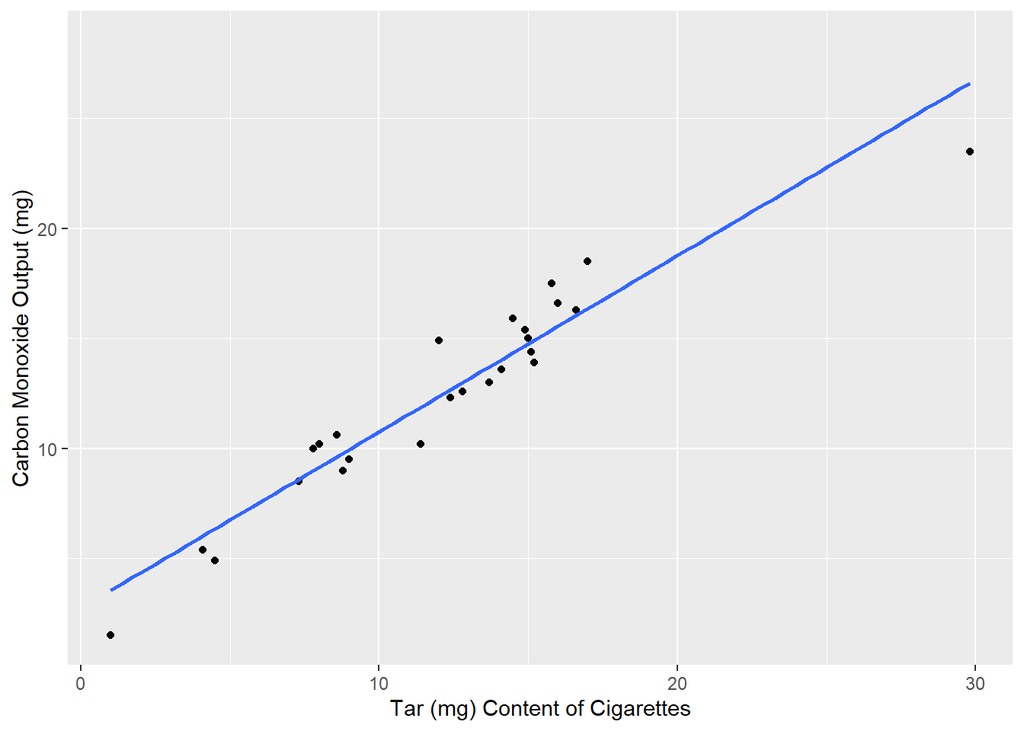

```r
gf_point(co~tar, data=cigs, xlab="Tar (mg) Content of Cigarettes", ylab="Carbon Monoxide Output (mg)") |>
  gf_lm()
```

```r
model_tar<-lm(co~tar, data=cigs)
```

### Assess Model Fit

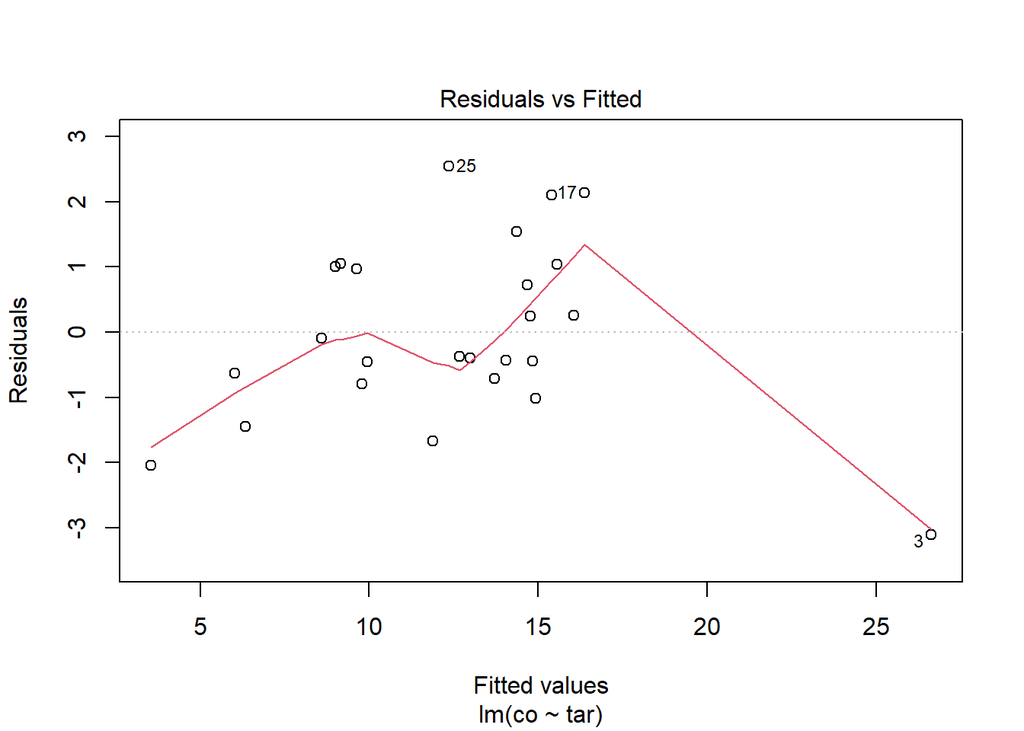

```r
plot(model_tar, 1)  #Residual Plot
```

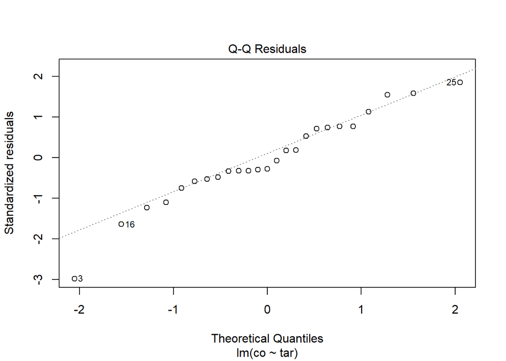

```r
plot(model_tar,2)  #QQ Plot
```

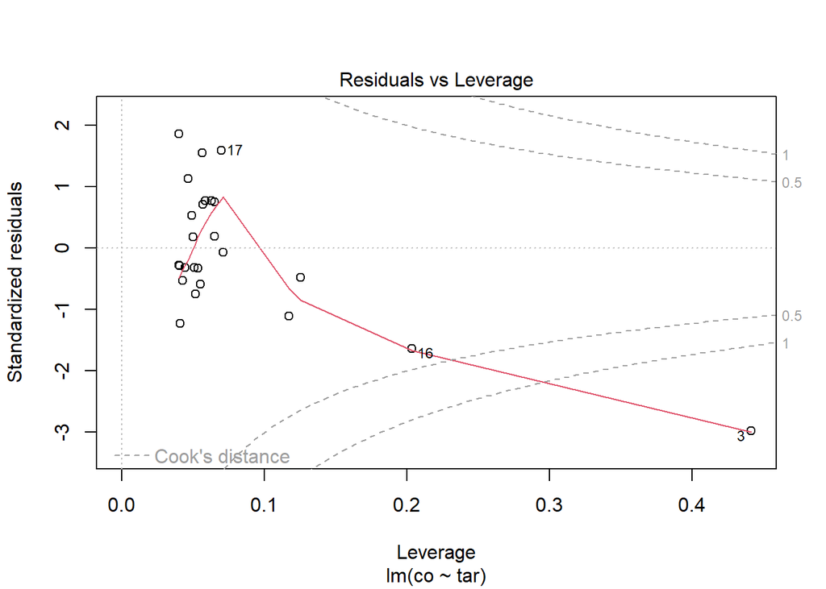

```r
plot(model_tar,5)  #Cook's Distance
```

We have constructed a model to estimate the parameters associated with the model:

$$y_{CO} = \beta_0 + \beta_1x_{tar}$$

We can test the following hypothesis:

> $H_0: \beta_1 = 0$  
> The slope of the linear model between CO and Tar is equal to zero (no linear relationship)

> $H_1: \beta_1 \neq 0$  
> The slope of the linear model between CO and Tar is not equal to zero (there is a linear relationship)

```r
anova(model_tar)
```

```
Analysis of Variance Table

Response: co
          Df Sum Sq Mean Sq F value    Pr(>F)
tar        1 494.28  494.28  253.37 6.552e-14 ***
Residuals 23  44.87    1.95
---
Signif. codes:  0 '***' 0.001 '**' 0.01 '*' 0.05 '.' 0.1 ' ' 1
```

```r
summary(model_tar)
```

```
Call:
lm(formula = co ~ tar, data = cigs)

Residuals:
    Min      1Q  Median      3Q     Max
-3.1124 -0.7167 -0.3754  1.0091  2.5450

Coefficients:
            Estimate Std. Error t value Pr(>|t|)
(Intercept)  2.74328    0.67521   4.063 0.000481 ***
tar          0.80098    0.05032  15.918 6.55e-14 ***
---
Signif. codes:  0 '***' 0.001 '**' 0.01 '*' 0.05 '.' 0.1 ' ' 1

Residual standard error: 1.397 on 23 degrees of freedom
Multiple R-squared:  0.9168,    Adjusted R-squared:  0.9132
F-statistic: 253.4 on 1 and 23 DF,  p-value: 6.552e-14
```

Here are some tips for writing output in line with the code for regression. The intercept of the model is 2.7432776 and the slope is 0.800976. The proportion of variability of CO output explained by the linear model with Tar is 0.9167782

The probability of observing a t-value of 15.9175924 or more extreme is 6.5522448^{-14} assuming the null hypothesis is true and the slope is zero.

```r
confint(model_tar,"tar", level=0.95)
```

```
        2.5 %    97.5 %
tar 0.6968808 0.9050712
```

```r
predict(model_tar,interval="confidence",newdata=data.frame(tar=33))
```

```
       fit      lwr      upr
1 29.17548 26.93613 31.41484
```

```r
predict(model_tar,interval="predict",newdata=data.frame(tar=33))
```

```
       fit      lwr      upr
1 29.17548 25.51994 32.83103
```

## Evaluating the Influence of an Outlier

In your analysis of the co~tar model, you may have notice an outlier. The outlier is from observation on row 3 (how do I know this?).

```r
#print row 3 of the dataset
cigs[3,]
```

```
# A tibble: 1 × 5
  brand        tar nicotine weight    co
  <chr>      <dbl>    <dbl>  <dbl> <dbl>
1 BullDurham  29.8     2.03   1.16  23.5
```

We can obverse how that data point influences our model by removing it from the data set and observing our fit and assessment of fit. Note, this does not mean we get to ignore the outlier - the purpose is exploratory analysis.

```r
cigs_new<-cigs[-3,] #this removes row 3 from the data set
```

We can also filter out outliers using the `tidyverse`

```r
cigs |>
  filter(tar != 29.8)

cigs |>
  filter(tar < 29)
```

Use the data set without the outlier to rerun the fit and assessment of the model. What changes? What stays the same (or at least leads to similar conclusions)?

## Simple Linear Regression - Weight

Now we want to build a model for CO output based on the weight (g) of the cigarette.